# GR5205 HW4 - Residual Analysis and Lack-of-Fit Test

### d) Plot the residuals against Y , each predictor variable, and each two-factor interaction term on separate graphs. Also prepare a normal probability plot. Analyse your plots and summarize your ﬁndings.

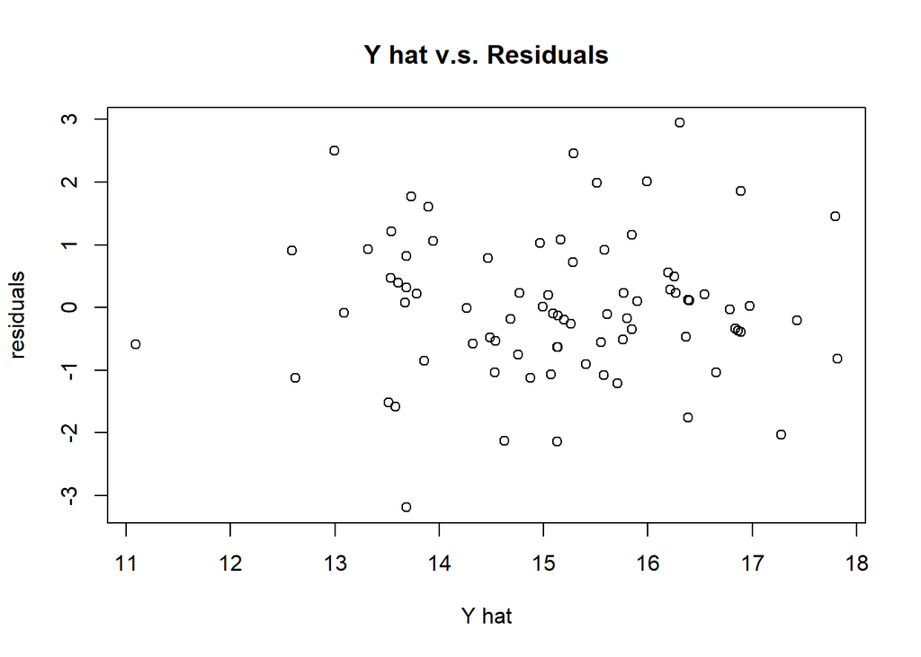

```r
plot(regr$fitted.values, regr$residuals, main="Y hat v.s. Residuals", xlab="Y hat", ylab="residuals")
```

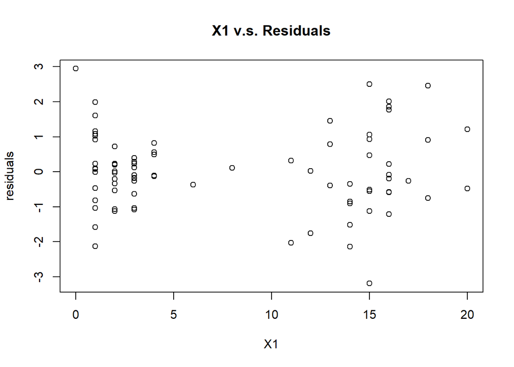

```r
plot(X1, regr$residuals, main="X1 v.s. Residuals", xlab="X1", ylab="residuals")
```

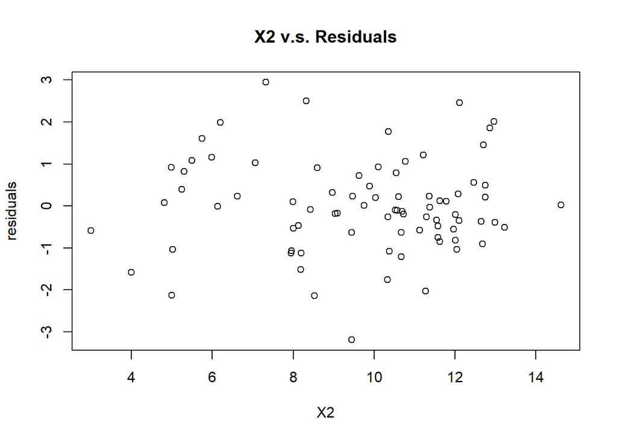

```r
plot(X2, regr$residuals, main="X2 v.s. Residuals", xlab="X2", ylab="residuals")
```

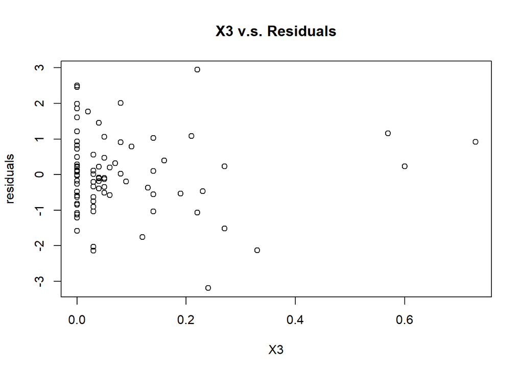

```r
plot(X3, regr$residuals, main="X3 v.s. Residuals", xlab="X3", ylab="residuals")
```

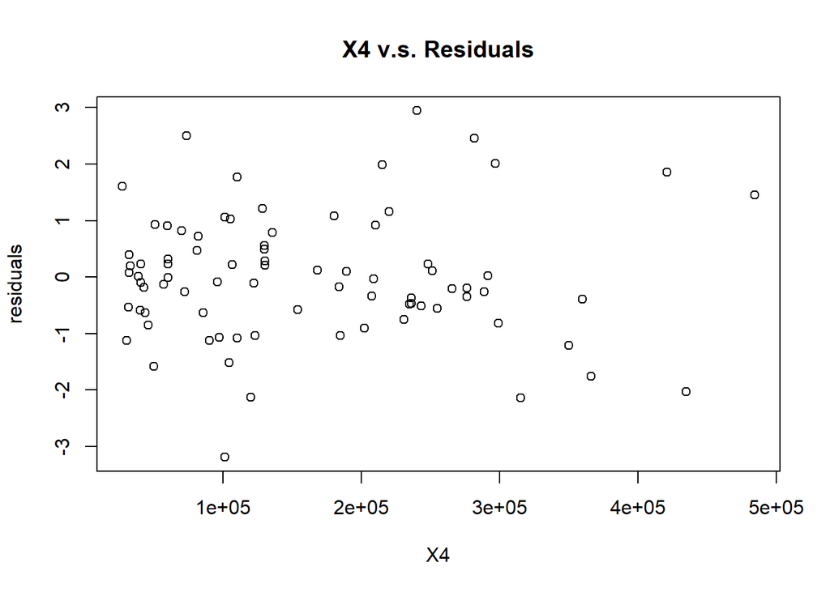

```r
plot(X4, regr$residuals, main="X4 v.s. Residuals", xlab="X4", ylab="residuals")
```

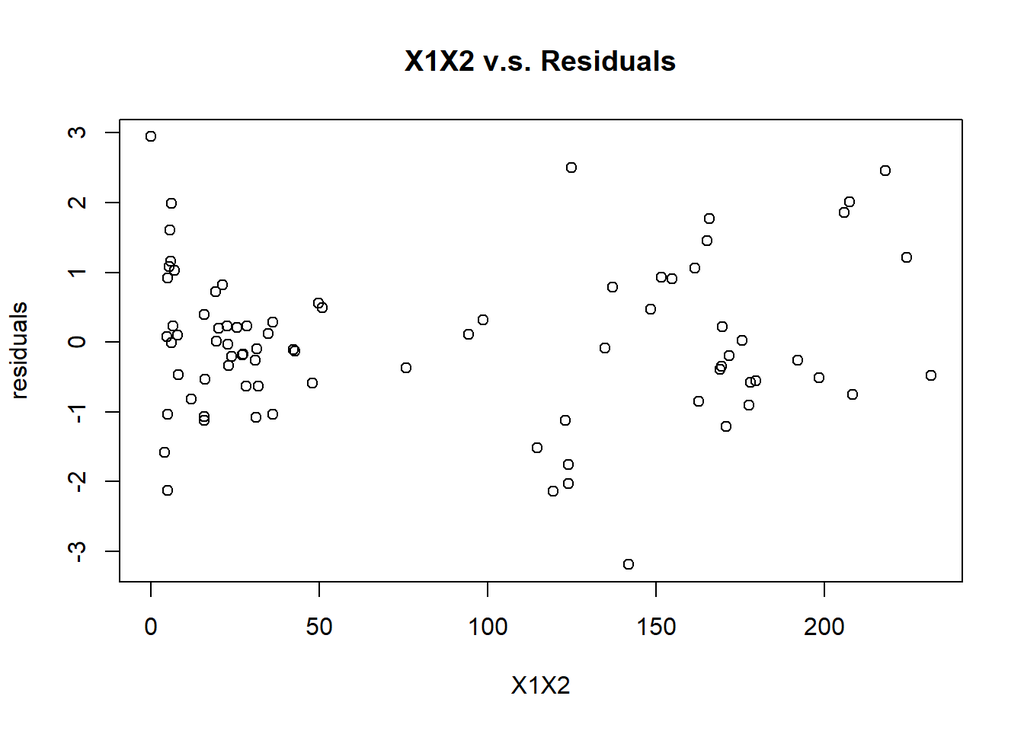

```r
plot(X1*X2,regr$residuals, main="X1X2 v.s. Residuals", xlab="X1X2", ylab="residuals")
```

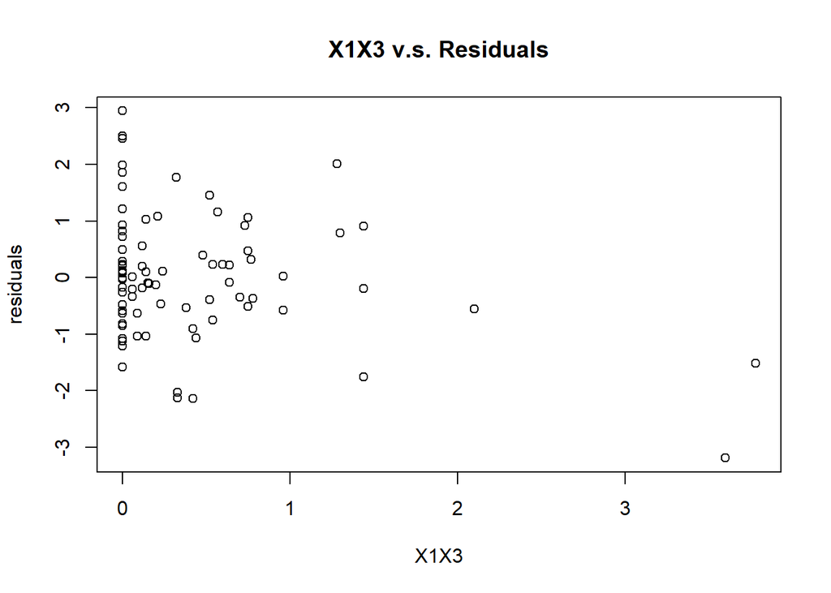

```r
plot(X1*X3,regr$residuals, main="X1X3 v.s. Residuals", xlab="X1X3", ylab="residuals")
```

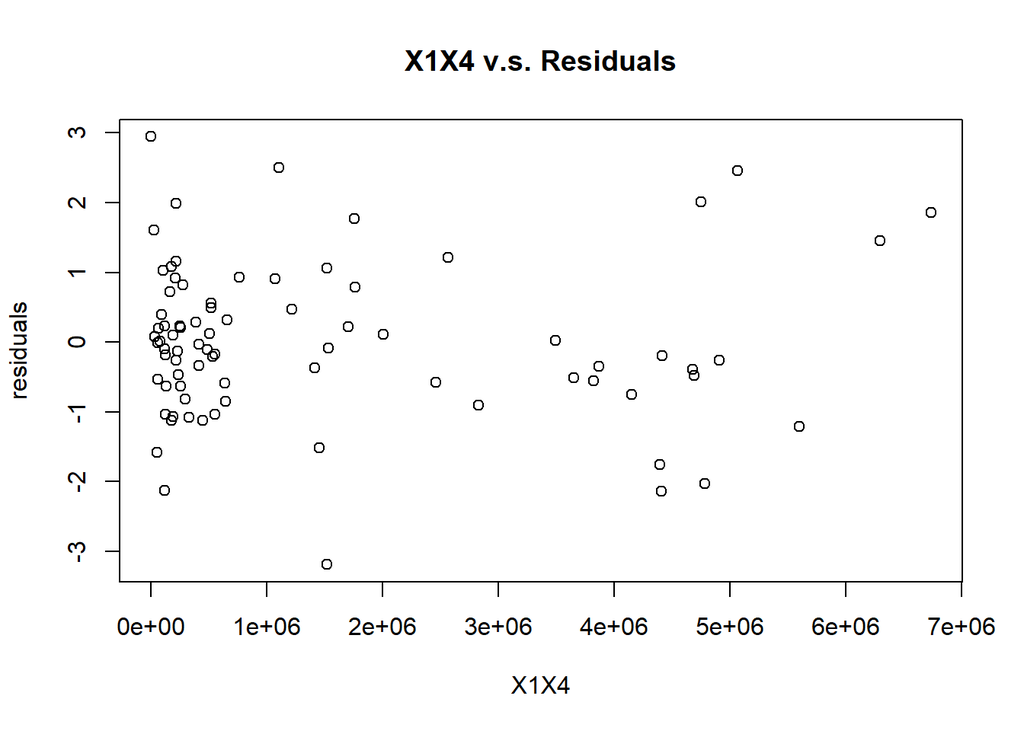

```r
plot(X1*X4,regr$residuals, main="X1X4 v.s. Residuals", xlab="X1X4", ylab="residuals")
```

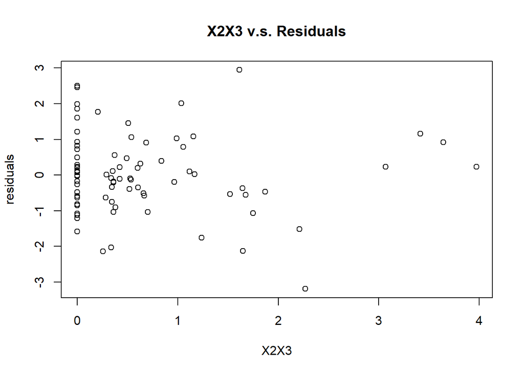

```r
plot(X2*X3,regr$residuals, main="X2X3 v.s. Residuals", xlab="X2X3", ylab="residuals")
```

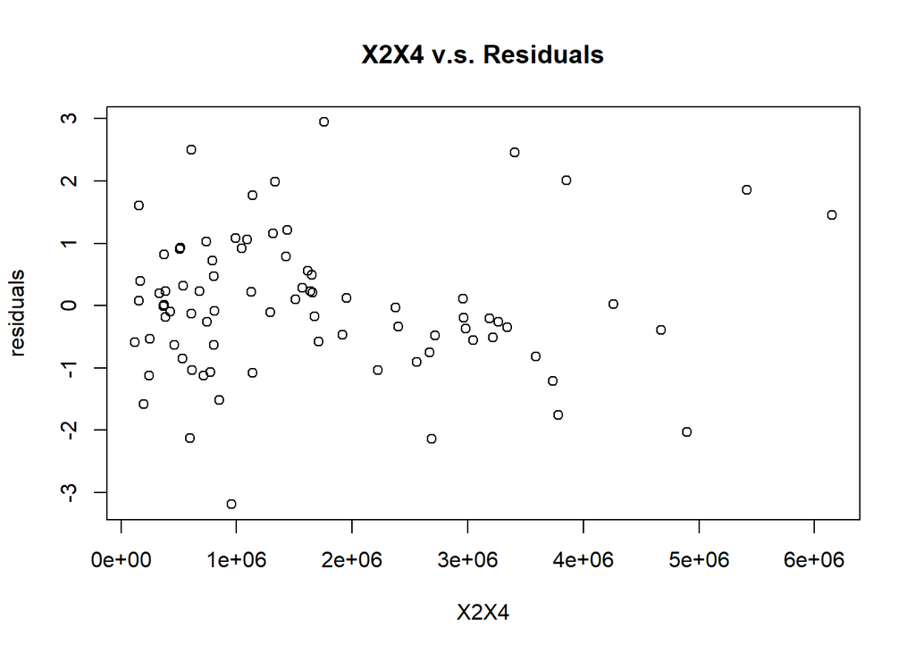

```r
plot(X2*X4,regr$residuals, main="X2X4 v.s. Residuals", xlab="X2X4", ylab="residuals")
```

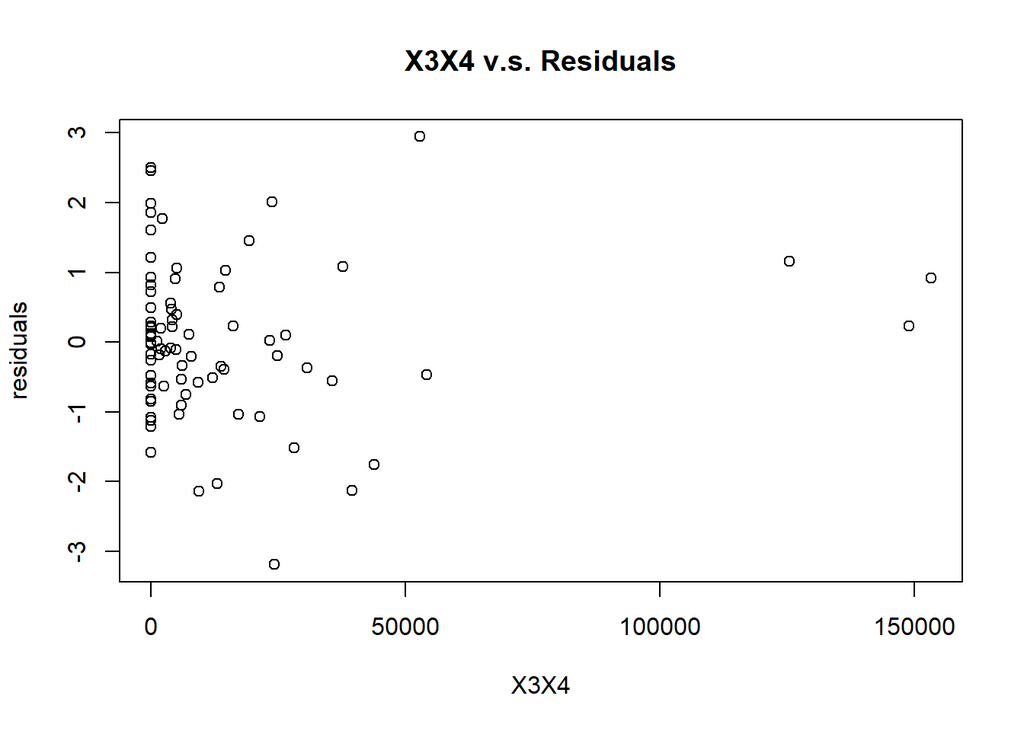

```r
plot(X3*X4,regr$residuals, main="X3X4 v.s. Residuals", xlab="X3X4", ylab="residuals")
```

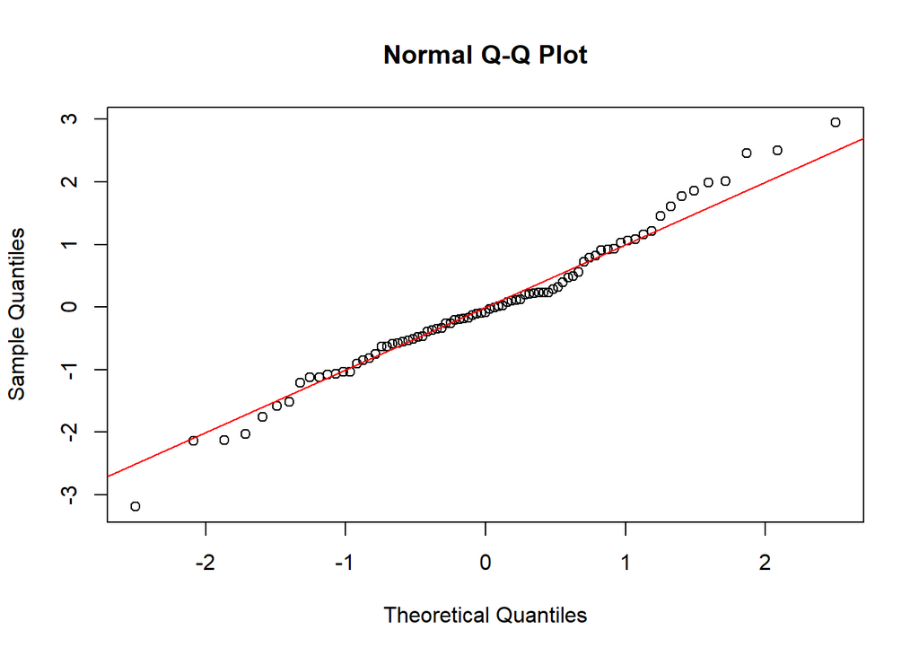

```r
qqnorm(regr$residuals)
abline(0,1,col="red")
```

The point in the residuals against fitted values plot seems to be normally distributed around 0, which indicates a good fit of linear regression model. The points in most of other polots also tend to be normally distributed around 0.

### (e)(5p) Can you conduct a formal test for lack of ﬁt here?

```r
summary(regr)
```

```
##
## Call:
## lm(formula = Y ~ X1 + X2 + X3 + X4)
##
## Residuals:
##     Min      1Q  Median      3Q     Max
## -3.1872 -0.5911 -0.0910  0.5579  2.9441
##
## Coefficients:
##               Estimate Std. Error t value Pr(>|t|)
## (Intercept)  1.220e+01  5.780e-01  21.110  < 2e-16 ***
## X1          -1.420e-01  2.134e-02  -6.655 3.89e-09 ***
## X2           2.820e-01  6.317e-02   4.464 2.75e-05 ***
## X3           6.193e-01  1.087e+00   0.570     0.57
## X4           7.924e-06  1.385e-06   5.722 1.98e-07 ***
## ---
## Signif. codes:  0 '***' 0.001 '**' 0.01 '*' 0.05 '.' 0.1 ' ' 1
##
## Residual standard error: 1.137 on 76 degrees of freedom
## Multiple R-squared:  0.5847, Adjusted R-squared:  0.5629
## F-statistic: 26.76 on 4 and 76 DF,  p-value: 7.272e-14
```

Since the F-Statistics is pretty large, and the p-value of F-Statistics is very small. we reject Ho: B1=B2=B3=B4=0

### f)(10p) The commercial real estate company obtained information about additional three properties. Find separate prediction intervals for the rental rates for each of the new properties. Use 95% conﬁdence coeﬃcient in each case. Can the rental rates of these three properties be predicted fairly precisely? What is the family conﬁdence level for the set of three predictions?

```r
predict(regr, data.frame(X1=c(4,6,12), X2=c(10,11.5,12.5), X3=c(0.1,0,0.32), X4=c(80000,120000,340000)), interval="prediction")
```

```
##        fit      lwr      upr
## 1 15.14850 12.85249 17.44450
## 2 15.54249 13.24504 17.83994
## 3 16.91384 14.53469 19.29299
```

Since the interval is relatively width, it is hard to tell the rental rates can be predicted fairly precisely.

The family confidence level is 0.95^3=0.857.

### (g)(10p) Obtain the analysis of variance table that decomposes the regression sum of squares into extra sums of squares associated with X4; with X1 given X4; with X2 given X1 and X4; and with X3, given X1, X2 and X4.

```r
new_model = lm(Y~X4+X1+X2+X3)
anova(new_model)
```

```
## Analysis of Variance Table
##
## Response: Y
##           Df Sum Sq Mean Sq F value    Pr(>F)
## X4         1 67.775  67.775 52.4369 3.073e-10 ***
## X1         1 42.275  42.275 32.7074 2.004e-07 ***
## X2         1 27.857  27.857 21.5531 1.412e-05 ***
## X3         1  0.420   0.420  0.3248    0.5704
## Residuals 76 98.231   1.293
## ---
## Signif. codes:  0 '***' 0.001 '**' 0.01 '*' 0.05 '.' 0.1 ' ' 1
```

From the table above, we can conclude: SSR(X4)=67.775,

SSR(X1|X4)=42.275,

SSR(X2|X1,X4)=27.857,

SSR(X3|X2,X1,X4)=0.420

### (h)(5p) Test whether X3 can be dropped from the regression model given that X1, X2, and X4 are retained. Use the F ∗ test statistic and level of signiﬁcance 0.01. State the alternatives decision rule, and conclusion. What is the p-value of the test?

```r
regr_without_x3=lm(Y~X1+X2+X4)
anova(regr,regr_without_x3)
```

```
## Analysis of Variance Table
##
## Model 1: Y ~ X1 + X2 + X3 + X4
## Model 2: Y ~ X1 + X2 + X4
##   Res.Df    RSS Df Sum of Sq      F Pr(>F)
## 1     76 98.231
## 2     77 98.650 -1  -0.41975 0.3248 0.5704
```

Ho: B3 = 0 H1: B3 != 0

## Problem 2

### (a)(5p) Explain the meaning of all regression coeﬃcients in the model.

Yi = β0 + β1Xi1 + β2Xi2 + εi β0: the estimated value of number of minutes spent on the service call when 0 of copy serviced and large commercial copier; β1: The marginal increase (decrease) of number of copies serviced given other variables fixed; β2: The marginal increase (decrease) of small copy model given other variables fixed;

### (b)(5p) Fit the regression model and state the estimated regression function.

```r
full=read.table("Homework_4_data_Problem2.txt",head=FALSE, col.names = c('Y','X1','X2'))
Y=full$Y
X1=full$X1
X2=full$X2
regr = lm(Y~X1+X2)
regr
```

```
##
## Call:
## lm(formula = Y ~ X1 + X2)
##
## Coefficients:
## (Intercept)           X1           X2
##     -0.9225      15.0461       0.7587
```

Y hat= -0.9225 + 15.0461X1 + 0.7587X2

### (c)(5p) Estimate the effect of copier model on mean service time with a 95 percent confidence interval. Interpret your interval estimate.

```r
confint(regr,level=0.95)
```

```
##                 2.5 %    97.5 %
## (Intercept) -7.177891  5.332945
## X1          14.057283 16.035004
## X2          -4.851254  6.368698
```

The effect of copier model on mean service time is 0.7587 (from question b.), with a 95% Confidence interval (-4.851254, 6.368698).

### (d)(10p) Why would the analyst wish to include X1, number of copiers, in the regression model when interest is in estimating the eﬀect of type of copier model on service time?

```r
regr_without_X1=lm(Y~X2)
summary(regr_without_X1)
```

```
##
## Call:
## lm(formula = Y ~ X2)
##
## Residuals:
##     Min      1Q  Median      3Q     Max
## -69.412 -38.412  -1.607  33.393  77.393
##
## Coefficients:
##             Estimate Std. Error t value Pr(>|t|)
## (Intercept)   78.607      8.150   9.645 2.55e-12 ***
## X2            -6.195     13.260  -0.467    0.643
## ---
## Signif. codes:  0 '***' 0.001 '**' 0.01 '*' 0.05 '.' 0.1 ' ' 1
##
## Residual standard error: 43.13 on 43 degrees of freedom
## Multiple R-squared:  0.005051,   Adjusted R-squared:  -0.01809
## F-statistic: 0.2183 on 1 and 43 DF,  p-value: 0.6427
```

```r
anova(regr, regr_without_X1)
```

```
## Analysis of Variance Table
##
## Model 1: Y ~ X1 + X2
## Model 2: Y ~ X2
##   Res.Df   RSS Df Sum of Sq      F    Pr(>F)
## 1     42  3410
## 2     43 79971 -1    -76560 942.88 < 2.2e-16 ***
## ---
## Signif. codes:  0 '***' 0.001 '**' 0.01 '*' 0.05 '.' 0.1 ' ' 1
```

The above result conclude that if we only fit the model with X2, then the p-value of B2 in Y=B0+B2*X2 is very large, indicating that its not a good model. On the other hand, the F-Test also suggest to include X1 in the linear regression model.

Therefore, the analyst need to include X1 to get more percisely prediction.

### (e)(10p) Obtain the residuals and plot them against X1X2. Is there any indication that an interaction term in the regression model would be helpful?

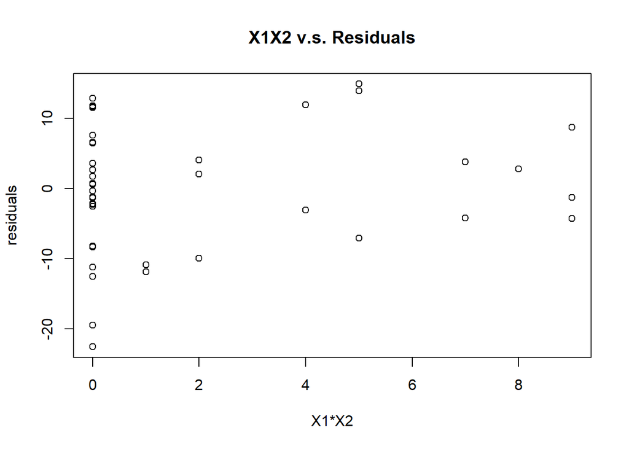

```r
plot(X1*X2, regr$residuals, main="X1X2 v.s. Residuals", xlab="X1*X2", ylab="residuals")
```

Since the data points seem to be normally distributed around 0, X1*X2 may be helpful.

### (f)(5p) Fit regression model with interaction term as an additional explanatory variable, i.e., Yi = β0 + β1Xi1 + β2Xi2 + β3Xi1Xi2 + εi

```r
regr2=lm(Y~X1+X2+X1*X2)
regr2
```

```
##
## Call:
## lm(formula = Y ~ X1 + X2 + X1 * X2)
##
## Coefficients:
## (Intercept)           X1           X2        X1:X2
##       2.813       14.339       -8.141        1.777
```

### (g)(10p) Test whether the interaction term can be dropped from the model; control the α risk at 0.10. State the alternatives, decision rule, and conclusion. What is the p-value of the test? If the interaction cannot be dropped from the model, describe the nature of the interaction eﬀect.

```r
anova(regr2, regr)
```

```
## Analysis of Variance Table
##
## Model 1: Y ~ X1 + X2 + X1 * X2
## Model 2: Y ~ X1 + X2
##   Res.Df    RSS Df Sum of Sq     F  Pr(>F)
## 1     41 3154.4
## 2     42 3410.3 -1   -255.89 3.326 0.07549 .
## ---
## Signif. codes:  0 '***' 0.001 '**' 0.01 '*' 0.05 '.' 0.1 ' ' 1
```

H0: coefficient of X1*X2 = 0

H1: coefficient of X1*X2 != 0

decision rule: accept H0 if p-value >= 0.10; Otherwise reject H0

Nature of interaction effect: the co-effect when a small copy model and a certain # of copiers serviced are presented together